# Explorando una variable categórica: conteos y proporciones

Los conteos y proporciones se basan en la tabulación.

La tabulación contabiliza la frecuencia de aparición de cada valor único de una variable.  
Por ejemplo en el caso de nuestra especies de los pingüinos, tenemos 3 especies:

- Adelie:
- Gentoo
- Chinstrap

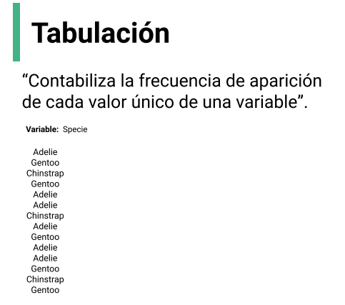

Para llevar un mejor control, podemos ordenar por orden alfabético o por cantidad de apariciones

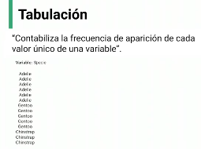

## Conteos

Una vez ordenados es más contar cuantos elementos tenemos de cada elemento único. Pero la palabra tabulación viene de tabla así que pasamos esto a una tabla y decir lo mismo pero de manera resumida. Para después realizar un diagrama de frecuencia. En el cual graficamos el numero de coincidencias por cada valor de la variable.

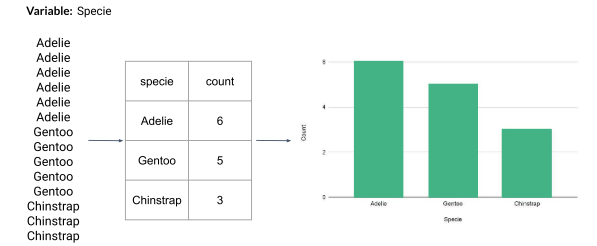

Así nosotros de manera visual podemos obtener información de la variable, en este caso podemos ver que la especie que mas ejemplares tiene es la Adelie y la que menos tiene es la Chinstrap.

Ademas puedes llevarlo a nivel mas arriba haciendo una segmentación por color a cada especie.

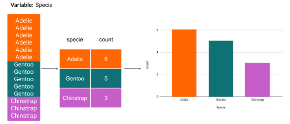

Así de esta forma el color nos ayuda aún mas a identificar a las especies. Así ya podemos asociar un color por especie en cada fase; desde conteo, tabulación, creación de gráficas, entre otros.

Este es la forma en que procedemos a realizar la etapa de conteos.

## Proporciones

La proporción se refiere a la relación de correspondencia entre las partes y el todo.

En el ejemplo anterior tuvimos una cantidad de 14 pingüinos exactamente, así los podemos clasificar por proporciones, cómo sigue:

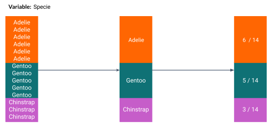

Esta división me dice la proporción que tengo con respecto de una variable y sus posibles valores. Esta manera es una forma sencilla de mostrar los conteos por proporciones.

Pasemos a realizarlo en Deepnote

```python
# Importando librerías
import empiricaldist
import janitor
import matplotlib.pyplot as plt
import numpy as np
import palmerpenguins
import pandas as pd
import scipy.stats
import seaborn as sns
import sklearn.metrics
import statsmodels.api as sm
import statsmodels.formula.api as smf
import statsmodels.stats as ss
import session_info
```

## Establecer apariencia general de las gráficas

```python
%matplotlib inline
sns.set_style(style='whitegrid')
sns.set_context(context='notebook')
plt.rcParams['figure.figsize'] = (11, 9.4)

penguin_color = {
    'Adelie': '#ff6602ff',
    'Gentoo': '#0f7175ff',
    'Chinstrap': '#c65dc9ff'
}
```

## Cargar los datos

### Datos crudos

```python
raw_penguins_df = pd.read_csv('dataset/penguins_raw.csv')
```

### Datos Preprocesados

**NOTA:** Puede que no usemos estos datos

```python
preprocessed_penguins_df = pd.read_csv('dataset/penguins.csv')
```

## Conteos y proporciones

Hagamos una pregunta, ¿qué parámetros estadísticos describen el conjunto de datos en general?

### Todas las variables

```python
preprocessed_penguins_df.describe()
```

|  | bill_length_mm | bill_depth_mm | flipper_length_mm | body_mass_g | year |
| --- | --- | --- | --- | --- | --- |
| count | 342.000000 | 342.000000 | 342.000000 | 342.000000 | 344.000000 |
| mean | 43.921930 | 17.151170 | 200.915205 | 4201.754386 | 2008.029070 |
| std | 5.459584 | 1.974793 | 14.061714 | 801.954536 | 0.818356 |
| min | 32.100000 | 13.100000 | 172.000000 | 2700.000000 | 2007.000000 |
| 25% | 39.225000 | 15.600000 | 190.000000 | 3550.000000 | 2007.000000 |
| 50% | 44.450000 | 17.300000 | 197.000000 | 4050.000000 | 2008.000000 |
| 75% | 48.500000 | 18.700000 | 213.000000 | 4750.000000 | 2009.000000 |
| max | 59.600000 | 21.500000 | 231.000000 | 6300.000000 | 2009.000000 |

La función anterior `describe()` nos ayuda a obtener algunos parámetros de nuestro conjunto de datos. **Hay que fijarnos que solo incluye los datos numéricos**, así que procederemos a incluir de todo tipo mediante el argumento `include='all'`.

Así me incluye las variables categóricas. Es decir incluye las que no son continuas o discretas.

```python
preprocessed_penguins_df.describe(include='all')
```

|  | species | island | bill_length_mm | bill_depth_mm | flipper_length_mm | body_mass_g | sex | year |
| --- | --- | --- | --- | --- | --- | --- | --- | --- |
| count | 344 | 344 | 342.000000 | 342.000000 | 342.000000 | 342.000000 | 333 | 344.000000 |
| unique | 3 | 3 | NaN | NaN | NaN | NaN | 2 | NaN |
| top | Adelie | Biscoe | NaN | NaN | NaN | NaN | male | NaN |
| freq | 152 | 168 | NaN | NaN | NaN | NaN | 168 | NaN |
| mean | NaN | NaN | 43.921930 | 17.151170 | 200.915205 | 4201.754386 | NaN | 2008.029070 |
| std | NaN | NaN | 5.459584 | 1.974793 | 14.061714 | 801.954536 | NaN | 0.818356 |
| min | NaN | NaN | 32.100000 | 13.100000 | 172.000000 | 2700.000000 | NaN | 2007.000000 |
| 25% | NaN | NaN | 39.225000 | 15.600000 | 190.000000 | 3550.000000 | NaN | 2007.000000 |
| 50% | NaN | NaN | 44.450000 | 17.300000 | 197.000000 | 4050.000000 | NaN | 2008.000000 |
| 75% | NaN | NaN | 48.500000 | 18.700000 | 213.000000 | 4750.000000 | NaN | 2009.000000 |
| max | NaN | NaN | 59.600000 | 21.500000 | 231.000000 | 6300.000000 | NaN | 2009.000000 |

La tabla anterior me incluye tanto valores `nulos`, debido a la inclusión de las variables categóricas con variables numéricas.

Para mantener orden lo que hacemos es analizar las variables categóricas y numéricas por separado.

### Analizando solo variables numéricas

```python
#Apoyándonos de ser explícitos en la inclusion
#de variables
preprocessed_penguins_df.describe(include=[np.number])
```

|  | bill_length_mm | bill_depth_mm | flipper_length_mm | body_mass_g | year |
| --- | --- | --- | --- | --- | --- |
| count | 342.000000 | 342.000000 | 342.000000 | 342.000000 | 344.000000 |
| mean | 43.921930 | 17.151170 | 200.915205 | 4201.754386 | 2008.029070 |
| std | 5.459584 | 1.974793 | 14.061714 | 801.954536 | 0.818356 |
| min | 32.100000 | 13.100000 | 172.000000 | 2700.000000 | 2007.000000 |
| 25% | 39.225000 | 15.600000 | 190.000000 | 3550.000000 | 2007.000000 |
| 50% | 44.450000 | 17.300000 | 197.000000 | 4050.000000 | 2008.000000 |
| 75% | 48.500000 | 18.700000 | 213.000000 | 4750.000000 | 2009.000000 |
| max | 59.600000 | 21.500000 | 231.000000 | 6300.000000 | 2009.000000 |

### Analizando solo variables categóricas

```python
# Apoyándonos de manera explicita en la inclusion
# de variables
preprocessed_penguins_df.describe(include=object)
```

|  | species | island | sex |
| --- | --- | --- | --- |
| count | 344 | 344 | 333 |
| unique | 3 | 3 | 2 |
| top | Adelie | Biscoe | male |
| freq | 152 | 168 | 168 |

Pero podemos obtenerlo de otra forma un poco más especial.

```python
(
    preprocessed_penguins_df
    .astype(
        {
            # Convierte la columna 'species' a tipo categórico
            'species': 'category',
            # Convierte la columna 'island' a tipo categórico
            'island': 'category',
            # Convierte la columna 'sex' a tipo categórico
            'sex': 'category'
        }
    )
    # Proporciona un resumen estadístico de las columnas categóricas
    .describe(include=['category', object])
)
```

|  | species | island | sex |
| --- | --- | --- | --- |
| count | 344 | 344 | 333 |
| unique | 3 | 3 | 2 |
| top | Adelie | Biscoe | male |
| freq | 152 | 168 | 168 |

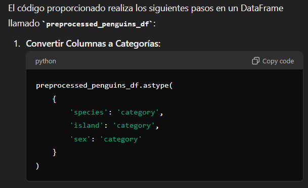

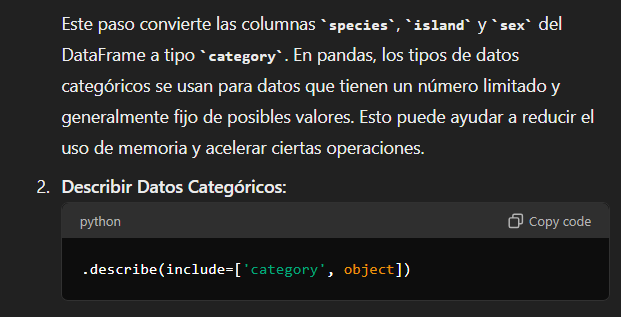

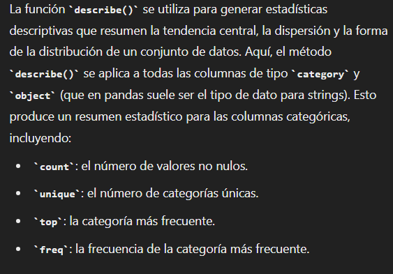

### ¿Cómo puedo visualizar los conteos de categorías?

#### Pandas

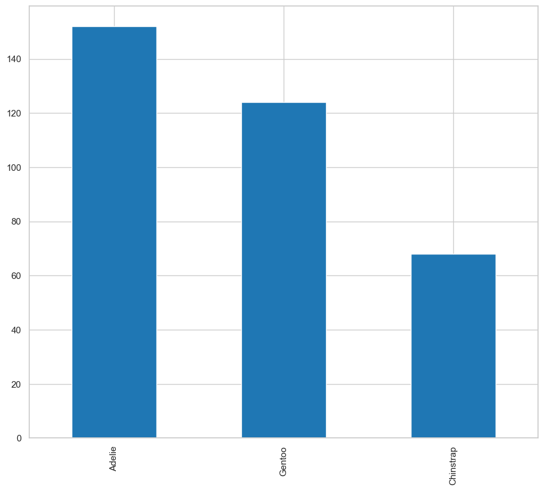

```python
(
    preprocessed_penguins_df
    .species
    .value_counts()
    .plot(kind='bar')

)
```

#### Seaborn

También existen las alternativas de hacerlo con otra biblioteca

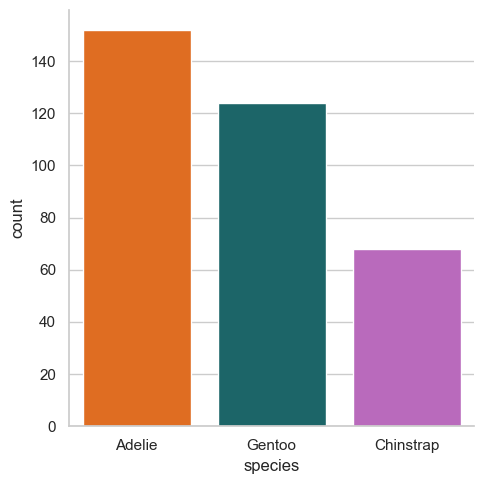

```python
sns.catplot(
    data=preprocessed_penguins_df,
    x='species',
    kind='count',
    palette=penguin_color
)
```

Otra manera en la cual podríamos graficar es a traves de la función `barplot()`

```python
(
    preprocessed_penguins_df
    .value_counts('species',sort=True)
)
```

```
species
Adelie       152
Gentoo       124
Chinstrap     68
dtype: int64
```

El código anterior es para obtener el numero de coincidencias de la especie de cada pingüino, ademas de ordenarlo de mayor a menor. Pero de la anterior forma no lo puede interpretar como una tabla, así que tenemos que resetear el index. Tenemos que poner un `.reset_index()`

```python
(
    preprocessed_penguins_df
    .value_counts('species',sort=True)
    .reset_index(name='counts')
)
```

|  | species | counts |
| --- | --- | --- |
| 0 | Adelie | 152 |
| 1 | Gentoo | 124 |
| 2 | Chinstrap | 68 |

De esta forma ya tenemos la representación en tabla, ahora lo único que falta hacer es graficarlo. Mediante una función `lambda`o anónima

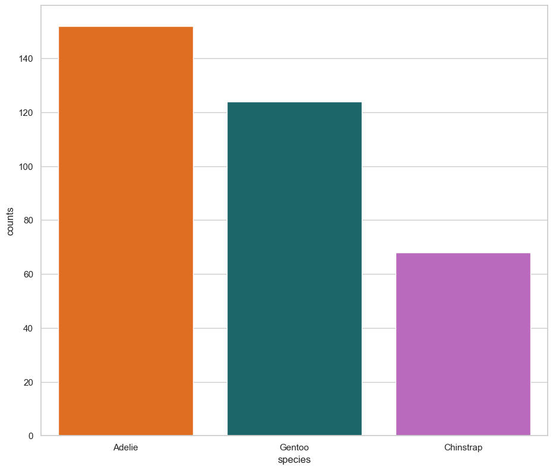

```python
(
    preprocessed_penguins_df
    .value_counts('species',sort=True)
    .reset_index(name='counts')
    .pipe(
        lambda df: (
            sns.barplot(
                data=df,
                x='species',
                y='counts',
                palette=penguin_color
            )

                    )
        )
)
```

#### Proporciones

Nosotros en las gráficas pasadas tenemos la frecuencia de aparición, pero ¿cómo podemos ver la proporción de cada valor?

Quizás, queramos saber ¿cuál es la proporción de cada specie respecto a una u otra, o en general?

Para visualizarlo, podemos hacerlo mediante Seaborn.

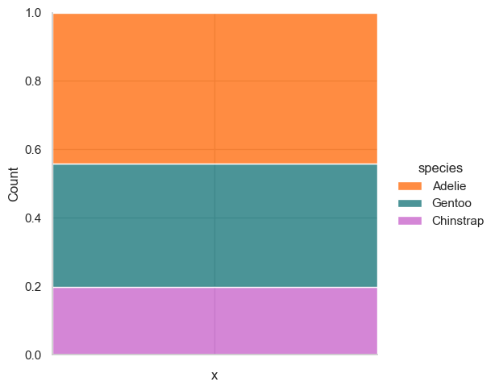

```python
(
    preprocessed_penguins_df
    .assign(x='') #Añade una columna vacía
    .pipe(
        lambda df: (
            sns.displot(
                data=df,
                x='x',
                hue='species',
                multiple='fill',
                palette=penguin_color
            )

        )
    )
)
```

Así ya tengo la proporción de las especies de los pingüinos.

Pero recordemos que tenemos 2 variables categóricas más que son la `Isla` y `Sexo` del pingüino.

Como una extensión puedes explorar las variables de manera individual.

### Extendiendo la idea de conteo

La idea de la extensión se le conoce como tabulación cruzada o tablas de contingencia, que permiten mezclar distintas variables categóricas para identificar proporciones o conteos respectivos.

Por ejemplo, tienes un pingüino en la isla, y podemos querer saber cuantos pingüinos 'Adelie' viven en cierta Isla, y así con las demás especies y con otras islas, para saber cual es su proporción. Por el momento continuaremos con una sola variable, ya que es lo que veremos en clases posteriores.

```python
#Veamos que variables
#categóricas tenemos nuevamente
preprocessed_penguins_df.describe(
    include=object
)
```

|  | species | island | sex |
| --- | --- | --- | --- |
| count | 344 | 344 | 333 |
| unique | 3 | 3 | 2 |
| top | Adelie | Biscoe | male |
| freq | 152 | 168 | 168 |

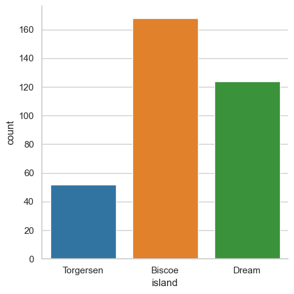

```python
sns.catplot(
    data=preprocessed_penguins_df,
    x='island',
    kind='count',
    hue_order='island',
)
```

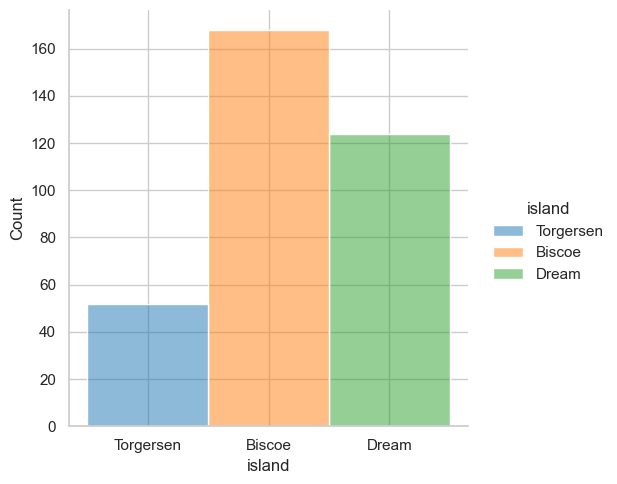

```python
sns.displot(
    data=preprocessed_penguins_df,
    x='island',
    hue='island',
)
```

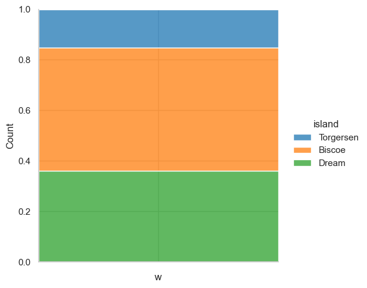

```python
(
    preprocessed_penguins_df
    .assign(w='') #Añade una columna vacía
    .pipe(
        lambda df: (
            sns.displot(
                data=df,
                x='w',
                hue='island',
                multiple='fill',
            )

        )
    )
)
```

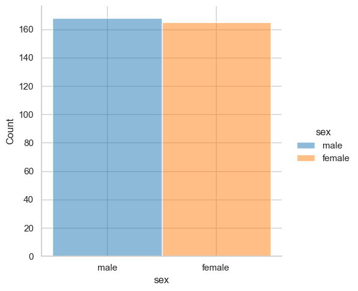

```python
sns.displot(
    data=preprocessed_penguins_df,
    x='sex',
    hue='sex',
)
```

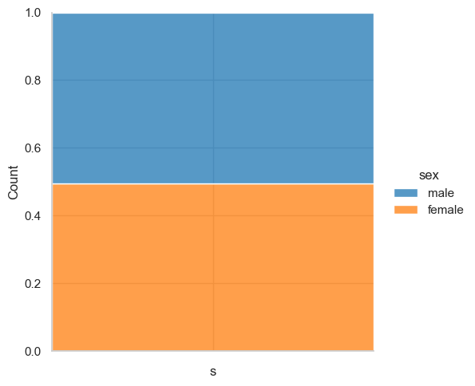

```python
(
    preprocessed_penguins_df
    .assign(s='') #Añade una columna vacía
    .pipe(
        lambda df: (
            sns.displot(
                data=df,
                x='s',
                hue='sex',
                multiple='fill',
            )

        )
    )
)
```

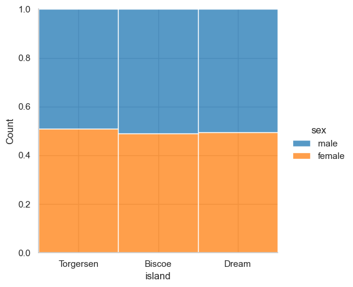

```python
sns.displot(
    data=preprocessed_penguins_df,
    x='island',
    hue='sex',
    multiple = 'fill'
)
```

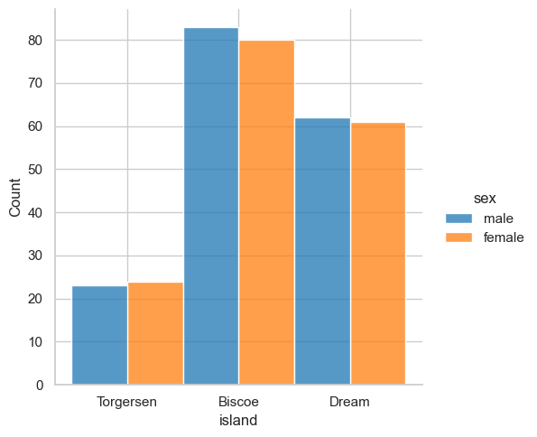

```python
sns.displot(
    data=preprocessed_penguins_df,
    x='island',
    hue='sex',
    multiple = 'dodge'
)
```

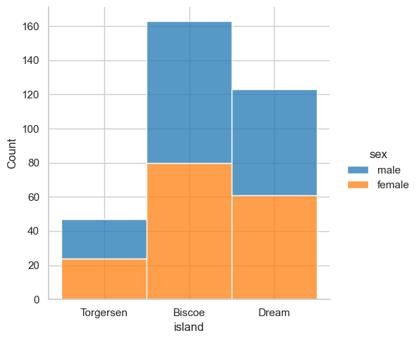

```python
sns.displot(
    data=preprocessed_penguins_df,
    x='island',
    hue='sex',
    multiple = 'stack'
)
```

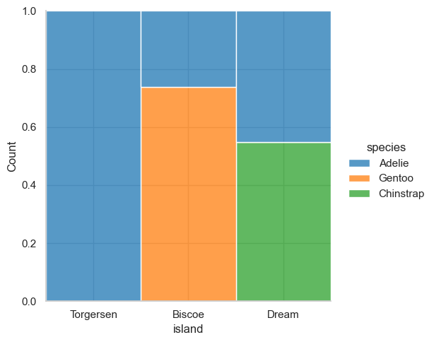

```python
sns.displot(
    data=preprocessed_penguins_df,
    x='island',
    hue='species',
    multiple = 'fill'
)
```

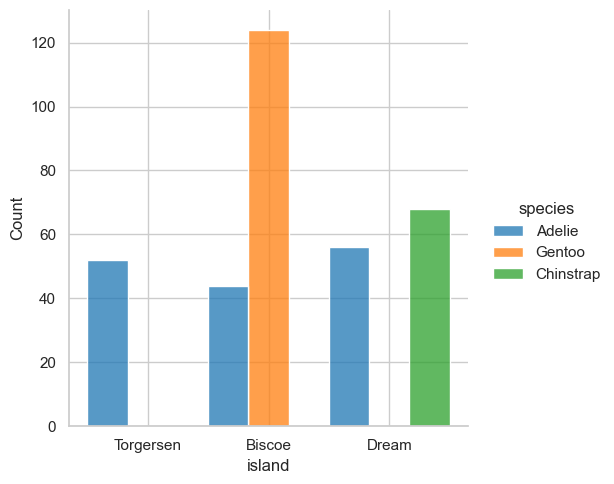

```python
sns.displot(
    data=preprocessed_penguins_df,
    x='island',
    hue='species',
    multiple = 'dodge'
)
```

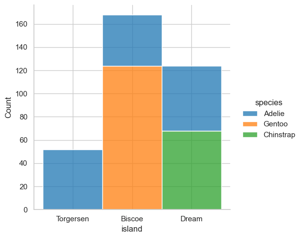

```python
sns.displot(
    data=preprocessed_penguins_df,
    x='island',
    hue='species',
    multiple = 'stack'
)
```

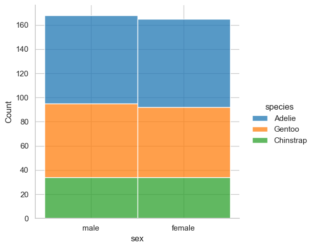

```python
sns.displot(
    data=preprocessed_penguins_df,
    x='sex',
    hue='species',
    multiple = 'stack'
)
```

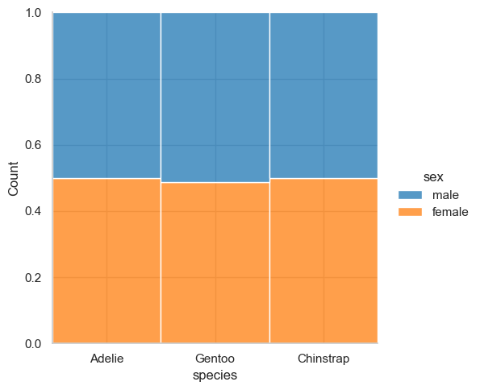

```python
sns.displot(
    data=preprocessed_penguins_df,
    x='species',
    hue='sex',
    multiple = 'fill'
)
```

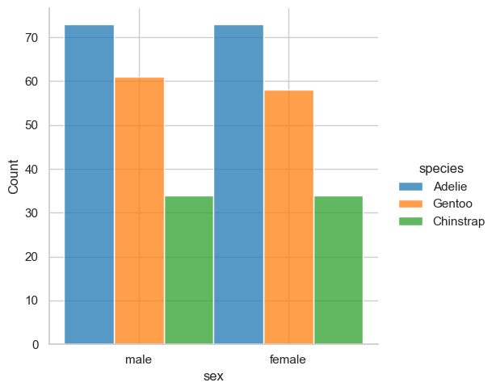

```python
sns.displot(
    data=preprocessed_penguins_df,
    x='sex',
    hue='species',
    multiple = 'dodge'
)
```

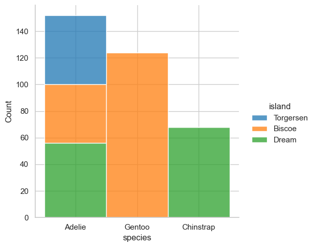

```python
sns.displot(
    data=preprocessed_penguins_df,
    x='species',
    hue='island',
    multiple = 'stack'
)
```